# doxyICU: analysis

John Kirkpatrick

03/05/2021

## Data quality

### Completeness

Proportion of data present for randomised patients, by variable

| Variable | Missing | Proportion |
| --- | --- | --- |
| Treatment | 0 | 0.00 |
| ICDate | 0 | 0.00 |
| Sex | 0 | 0.00 |
| Age | 0 | 0.00 |
| Temperature | 0 | 0.00 |
| OnsetDate | 0 | 0.00 |
| AdmissionDate | 0 | 0.00 |
| ICUAdmissionNeeded | 0 | 0.00 |
| PCRTest | 0 | 0.00 |
| Hypersensitivity | 0 | 0.00 |
| MyastheniaGravis | 0 | 0.00 |
| Cirrhosis | 0 | 0.00 |
| Dyspnea | 0 | 0.00 |
| Diarrhoea | 0 | 0.00 |
| Anosmia | 0 | 0.00 |
| Pneumonia | 0 | 0.00 |
| Rash | 0 | 0.00 |
| TrtDoxycycline | 0 | 0.00 |
| TrtAntibiotics | 0 | 0.00 |
| TrtDiabetes | 0 | 0.00 |
| TrtHeartFailure | 0 | 0.00 |
| TrtAntiHypertensives | 0 | 0.00 |
| TrtAntiDepressants | 0 | 0.00 |
| TrtCancer | 0 | 0.00 |
| TrtImmunosuppressant | 0 | 0.00 |
| TrtSteroids | 0 | 0.00 |
| TrtAntiCoagulantsProphylactic | 0 | 0.00 |
| TrtAntiCoagulantsTherapeutic | 0 | 0.00 |
| TrtFavipiravir | 0 | 0.00 |
| TrtHydroxychloroquine | 0 | 0.00 |
| TrtRemdesivir | 0 | 0.00 |
| TrtTocilizumab | 0 | 0.00 |
| TrtIvermectin | 0 | 0.00 |
| TrtOther | 0 | 0.00 |
| StratumILD | 0 | 0.00 |
| StratumCOPD | 0 | 0.00 |
| StratumBronchiectasis | 0 | 0.00 |
| StratumAsthma | 0 | 0.00 |
| StratumOtherLung | 0 | 0.00 |
| StratumDiabetes | 0 | 0.00 |
| StratumHeartDisease | 0 | 0.00 |
| StratumHypertension | 0 | 0.00 |
| StratumCancer | 0 | 0.00 |
| StratumOther | 0 | 0.00 |
| StratumCode | 0 | 0.00 |
| Stratum | 0 | 0.00 |
| Ethnicity | 1 | 0.26 |
| Alive | 1 | 0.26 |
| TrtAnalgesics | 1 | 0.26 |
| FinalStatus | 78 | 20.16 |
| TreatmentDuration | 80 | 20.67 |
| HospitalDischargeDate | 84 | 21.71 |
| FollowUpDate | 133 | 34.37 |
| TreatmentDiscontinuationReason | 152 | 39.28 |
| Pregnancy | 243 | 62.79 |
| TemperatureLocation | 255 | 65.89 |
| ICUAdmissionNeededDate | 312 | 80.62 |
| ICUAdmissionSuccess | 322 | 83.20 |
| RelatedDeath | 346 | 89.41 |
| DateOfDeath | 349 | 90.18 |
| ICUDischargeDate | 350 | 90.44 |
| ICUNonAdmissionReason | 359 | 92.76 |
| AENausea | 387 | 100.00 |
| AECramps | 387 | 100.00 |
| AEDiarrhoea | 387 | 100.00 |
| AETinnitus | 387 | 100.00 |
| AEGenitalSoreness | 387 | 100.00 |
| AERash | 387 | 100.00 |
| AEHeadache | 387 | 100.00 |
| AEVision | 387 | 100.00 |
| AEPalpitation | 387 | 100.00 |
| AEOther | 387 | 100.00 |

## Enrolment

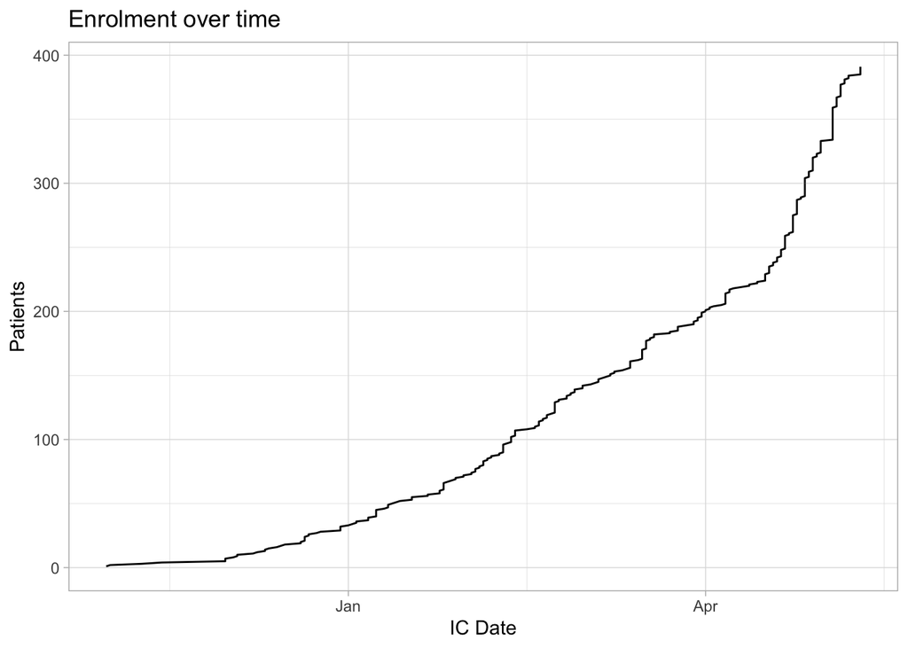

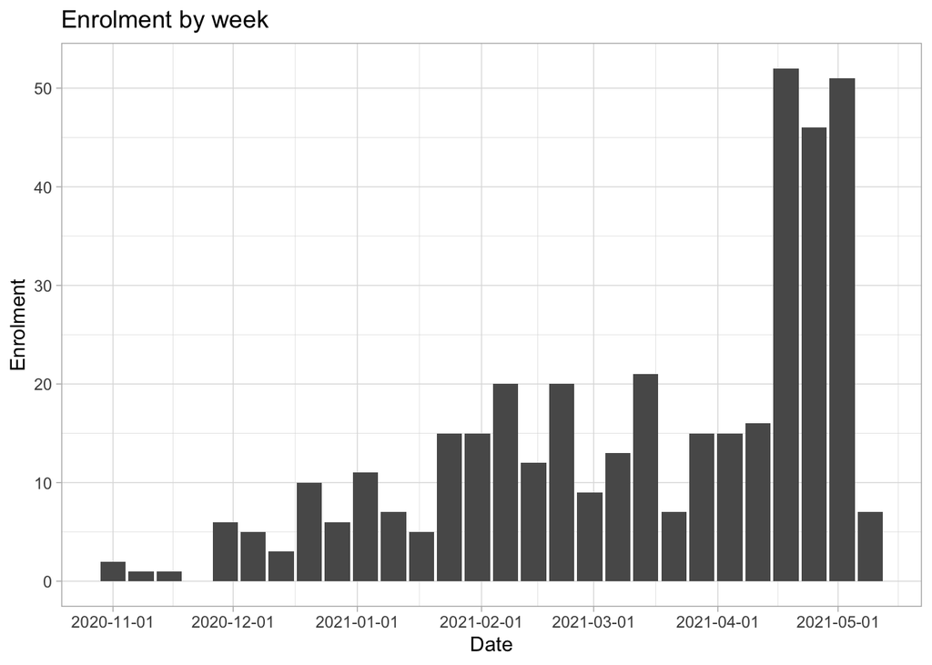

```
## # A tibble: 1 × 2
##   FPFV       LPFV
##   <date>     <date>
## 1 2020-11-01 2021-05-10
```

| WeekBeginning | Doxy | SOC | TotalDoxy | TotalSOC |
| --- | --- | --- | --- | --- |
| 2020-11-15 | 1 | 0 | 1 | 0 |
| 2020-11-29 | 2 | 4 | 3 | 4 |
| 2020-12-06 | 2 | 3 | 5 | 7 |
| 2020-12-13 | 1 | 2 | 6 | 9 |
| 2020-12-20 | 6 | 4 | 12 | 13 |
| 2020-12-27 | 1 | 5 | 13 | 18 |
| 2021-01-03 | 2 | 8 | 15 | 26 |
| 2021-01-10 | 5 | 2 | 20 | 28 |
| 2021-01-17 | 4 | 1 | 24 | 29 |
| 2021-01-24 | 7 | 8 | 31 | 37 |
| 2021-01-31 | 9 | 6 | 40 | 43 |
| 2021-02-07 | 12 | 7 | 52 | 50 |
| 2021-02-14 | 7 | 5 | 59 | 55 |
| 2021-02-21 | 8 | 12 | 67 | 67 |
| 2021-02-28 | 5 | 4 | 72 | 71 |
| 2021-03-07 | 6 | 7 | 78 | 78 |
| 2021-03-14 | 12 | 9 | 90 | 87 |
| 2021-03-21 | 4 | 3 | 94 | 90 |
| 2021-03-28 | 6 | 9 | 100 | 99 |
| 2021-04-04 | 9 | 6 | 109 | 105 |
| 2021-04-11 | 8 | 8 | 117 | 113 |
| 2021-04-18 | 24 | 26 | 141 | 139 |
| 2021-04-25 | 22 | 24 | 163 | 163 |
| 2021-05-02 | 26 | 25 | 189 | 188 |
| 2021-05-09 | 3 | 4 | 192 | 192 |
| 2020-11-01 | 0 | 2 | 192 | 194 |
| 2020-11-08 | 0 | 1 | 192 | 195 |

## Baseline demographics [Randomised patients]

### Demography

| Treatment | Age N | Age Mean | Age Min | Age Max |
| --- | --- | --- | --- | --- |
| Doxycycline | 192 | 58.6 | 40 | 90 |
| Standard of Care | 195 | 58.6 | 40 | 88 |

| Treatment | Temperature N | Temperature Mean | Temperature Min | Temperature Max |
| --- | --- | --- | --- | --- |
| Doxycycline | 192 | 38.3 | 38 | 41 |
| Standard of Care | 195 | 38.4 | 38 | 41 |

| Treatment | Sex Male | Sex Female |
| --- | --- | --- |
| Doxycycline | 123 | 69 |
| Standard of Care | 124 | 71 |

```
## # A tibble: 2 × 4
##   Treatment         Mean   Min   Max
##   <chr>            <dbl> <int> <int>
## 1 Doxycycline       58.6    40    90
## 2 Standard of Care  58.6    40    88
```

### Risk factors

In earlier versions of this file, the following table was incorrect.

Number of patients with x risk facors

| X | Doxycycline | SOC |
| --- | --- | --- |
| 0 | 48 | 49 |
| 2 | 3 | 7 |
| 3 | 44 | 44 |
| 4 | 55 | 52 |
| 5 | 40 | 34 |
| 6 | 2 | 8 |
| 7 | 0 | 1 |

### Stratification and sex

Sex by stratum

| Stratum | Male | Female |
| --- | --- | --- |
| LUNG | 50 | 34 |
| NONE | 66 | 31 |
| OTHER | 131 | 75 |

## Outcomes

### Deaths within 14 days of enrolment

Alive by Stratum

| Stratum | Alive No | Alive Yes |
| --- | --- | --- |
| LUNG | 9 | 75 |
| NONE | 4 | 93 |
| OTHER | 26 | 179 |
| NA | 0 | 0 |

### ICU admission

ICUAdmissionNeeded by Stratum

| Stratum | ICUAdmissionNeeded No | ICUAdmissionNeeded Yes |
| --- | --- | --- |
| LUNG | 66 | 18 |
| NONE | 85 | 12 |
| OTHER | 159 | 47 |
| NA | 0 | 0 |

ICUAdmissionSuccess by Stratum

| Stratum | ICUAdmissionSuccess No | ICUAdmissionSuccess Yes |
| --- | --- | --- |
| LUNG | 7 | 9 |
| NONE | 2 | 8 |
| OTHER | 18 | 21 |
| NA | 0 | 0 |

ICUNonAdmissionReason by Stratum

| Stratum | ICUNonAdmissionReason Lack of beds | ICUNonAdmissionReason Patient unsuitable | ICUNonAdmissionReason Patient declined | ICUNonAdmissionReason Other |
| --- | --- | --- | --- | --- |
| LUNG | 3 | 4 | 0 | 0 |
| NONE | 2 | 0 | 0 | 0 |
| OTHER | 9 | 9 | 0 | 0 |

### Final status etc

Alive by Stratum

| Stratum | Alive No | Alive Yes |
| --- | --- | --- |
| LUNG | 9 | 75 |
| NONE | 4 | 93 |
| OTHER | 26 | 179 |
| NA | 0 | 0 |

FinalStatus by Stratum

| Stratum | FinalStatus Complete | FinalStatus Early discharge | FinalStatus TRAE | FinalStatus Non-Trt | FinalStatus Lost | FinalStatus Consent | FinalStatus Other | FinalStatus Died |
| --- | --- | --- | --- | --- | --- | --- | --- | --- |
| LUNG | 25 | 41 | 2 | 1 | 0 | 0 | 0 | 0 |
| NONE | 22 | 56 | 2 | 1 | 0 | 0 | 0 | 0 |
| OTHER | 36 | 115 | 2 | 5 | 0 | 0 | 0 | 0 |
| NA | 0 | 0 | 0 | 0 | 0 | 0 | 0 | 0 |

TreatmentDiscontinuationReason by Stratum

| Stratum | TreatmentDiscontinuationReason Improved/Discharged | TreatmentDiscontinuationReason Other |
| --- | --- | --- |
| LUNG | 44 | 2 |
| NONE | 60 | 2 |
| OTHER | 123 | 4 |
| NA | 0 | 0 |

# Results by treatment group [as randomised]

## Stratification and treatment

Stratification risk factors, by treatment group

| Stratum | Doxycycline | SOC |
| --- | --- | --- |
| ILD | 1.56 | 1.03 |
| COPD | 10.42 | 7.69 |
| Bronchiectasis | 1.04 | 1.03 |
| Asthma | 6.77 | 8.21 |
| OtherLung | 3.65 | 4.62 |
| Diabetes | 33.85 | 37.44 |
| HeartDisease | 14.58 | 12.31 |
| Hypertension | 52.60 | 53.85 |
| Cancer | 1.04 | 1.54 |
| Other | 42.71 | 41.54 |

Concomitant treatments, by treatment group

| Stratum | Doxycycline | SOC |
| --- | --- | --- |
| Doxycycline | 92.71 | 2.56 |
| Antibiotics | 82.29 | 80.00 |
| Analgesics | 29.69 | 22.68 |
| Diabetes | 36.46 | 37.95 |
| HeartFailure | 4.69 | 8.21 |
| AntiHypertensives | 52.60 | 50.77 |
| AntiDepressants | 1.56 | 1.03 |
| Cancer | 1.56 | 0.00 |
| Immunosuppressant | 2.60 | 3.08 |
| Steroids | 83.33 | 79.49 |
| AntiCoagulantsProphylactic | 66.15 | 51.79 |
| AntiCoagulantsTherapeutic | 24.48 | 32.31 |
| Favipiravir | 7.29 | 8.21 |
| Hydroxychloroquine | 1.56 | 0.00 |
| Remdesivir | 86.98 | 81.03 |
| Tocilizumab | 0.00 | 2.05 |
| Ivermectin | 41.15 | 37.44 |
| Other | 63.02 | 64.62 |

Patients randomised to doxycycline who did not receive doxycycline

| SiteID | PatNo | Treatment | TrtDoxycycline |
| --- | --- | --- | --- |
| 018 | 0007 | Doxycycline | 0 |
| 018 | 0011 | Doxycycline | 0 |
| 018 | 0016 | Doxycycline | 0 |
| 018 | 0017 | Doxycycline | 0 |
| 018 | 0019 | Doxycycline | 0 |
| 018 | 0020 | Doxycycline | 0 |
| 018 | 0021 | Doxycycline | 0 |
| 018 | 0025 | Doxycycline | 0 |
| 008 | 0188 | Doxycycline | 0 |
| 008 | 0198 | Doxycycline | 0 |
| 008 | 0211 | Doxycycline | 0 |
| 008 | 0216 | Doxycycline | 0 |
| 008 | 0220 | Doxycycline | 0 |
| 008 | 0231 | Doxycycline | 0 |

Patients randomised to standard of care who received doxycycline

| SiteID | PatNo | Treatment | TrtDoxycycline |
| --- | --- | --- | --- |
| 020 | 0007 | Standard of Care | 1 |
| 020 | 0009 | Standard of Care | 1 |
| 012 | 0001 | Standard of Care | 1 |
| 018 | 0008 | Standard of Care | 1 |
| 008 | 0154 | Standard of Care | 1 |

Treatment by stratum

| Treatment | LUNG | NONE | OTHER |
| --- | --- | --- | --- |
| Doxycycline | 41 | 48 | 103 |
| Standard of Care | 43 | 49 | 103 |

Need for ICU admission, by treatment

| Treatment | ICU Admission No | ICU Admission Yes | Pct needed |
| --- | --- | --- | --- |
| Doxycycline | 161 | 31 | 16.1 |
| Standard of Care | 149 | 46 | 23.6 |

Need for ICU admission, by treatment and site

| Site | Standard of care No | Standard of care Yes | Standard of care Pct needed | Doxycycline No | Doxycycline Yes | Doxycycline Pct needed |
| --- | --- | --- | --- | --- | --- | --- |
| 008 | 88 | 34 | 27.9 | 97 | 23 | 19.2 |
| 011 | 18 | 0 | 0.0 | 27 | 0 | 0.0 |
| 012 | 11 | 5 | 31.2 | 11 | 3 | 21.4 |
| 013 | 4 | 0 | 0.0 | 1 | 0 | 0.0 |
| 018 | 13 | 0 | 0.0 | 10 | 2 | 16.7 |
| 020 | 15 | 7 | 31.8 | 15 | 3 | 16.7 |

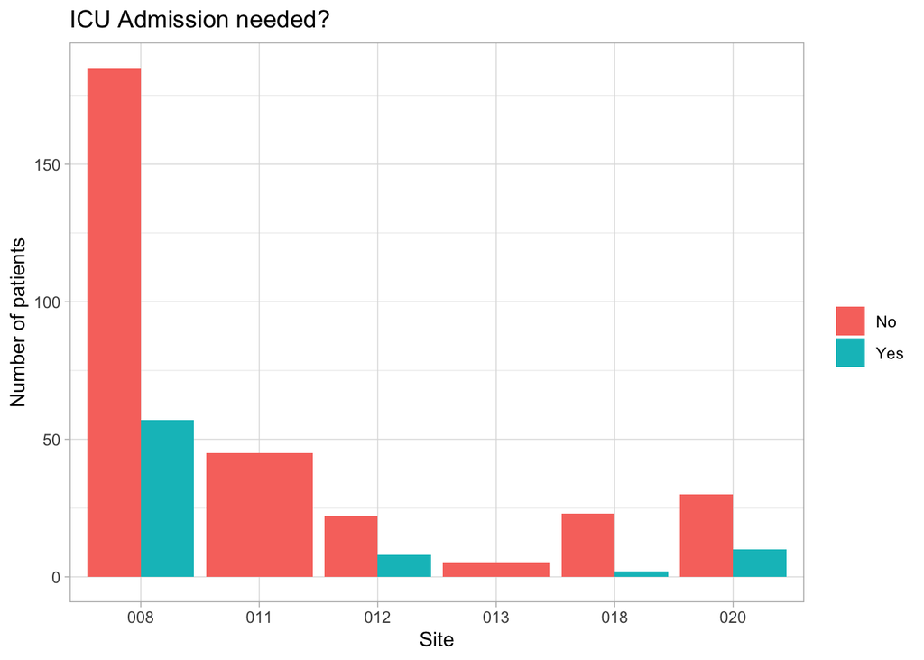

Need for ICU admission or death within 14 days, by treatment

| Treatment | ICU Admission or death No | ICU Admission or death Yes | Pct admitted |
| --- | --- | --- | --- |
| Doxycycline | 161 | 31 | 16.1 |
| Standard of Care | 149 | 46 | 23.6 |

Need for ICU admission or death, by treatment and site

| Site | Standard of care No | Standard of care Yes | Standard of care Pct | Doxycycline No | Doxycycline Yes | Doxycycline Pct |
| --- | --- | --- | --- | --- | --- | --- |
| 008 | 88 | 34 | 27.9 | 97 | 23 | 19.2 |
| 011 | 18 | 0 | 0.0 | 27 | 0 | 0.0 |
| 012 | 11 | 5 | 31.2 | 11 | 3 | 21.4 |
| 013 | 4 | 0 | 0.0 | 1 | 0 | 0.0 |
| 018 | 13 | 0 | 0.0 | 10 | 2 | 16.7 |
| 020 | 15 | 7 | 31.8 | 15 | 3 | 16.7 |

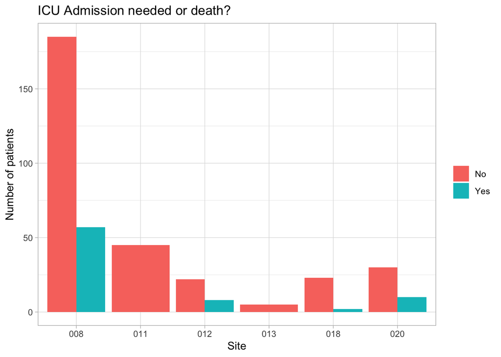

Survival by treatment

| Treatment | Alive? No | Alive? Yes | Alive? Unknown | Pct Alive |
| --- | --- | --- | --- | --- |
| Doxycycline | 19 | 173 | 0 | 90.1 |
| Standard of Care | 20 | 174 | 1 | 89.7 |

Note:  
The status of patient 008-0017 is unknown.

| Site | Standard of care No | Standard of care Yes | Standard of care Pct alive | Doxycycline No | Doxycycline Yes | Doxycycline Pct alive |
| --- | --- | --- | --- | --- | --- | --- |
| 008 | 17 | 104 | 86.0 | 17 | 103 | 85.8 |
| 011 | 0 | 18 | 100.0 | 0 | 27 | 100.0 |
| 012 | 1 | 15 | 93.8 | 1 | 13 | 92.9 |
| 013 | 0 | 4 | 100.0 | 0 | 1 | 100.0 |
| 018 | 0 | 13 | 100.0 | 0 | 12 | 100.0 |
| 020 | 2 | 20 | 90.9 | 1 | 17 | 94.4 |

Note:  
The status of patient 008-0017 is unknown. They are omitted from this table.

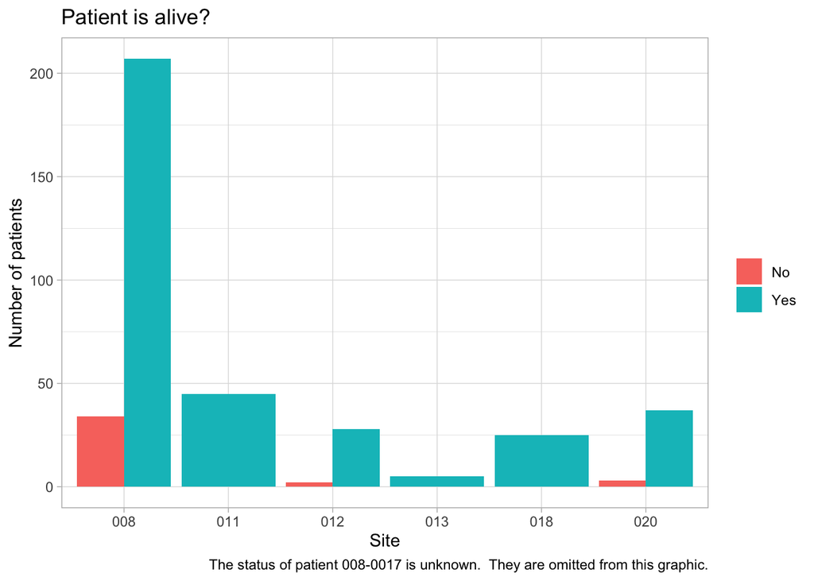

### Disposition of patients needing admission to ICU

Patients who are known not to be alive, for whom ICU admission was needed but was not successful

| Site | PatNo | Trt | Hosp Admit | ICDate | ICU Needed | ICU Date | Reason | Alive | Date of Death |
| --- | --- | --- | --- | --- | --- | --- | --- | --- | --- |
| 020 | 0020 | Standard of Care | 2021-01-08 | 2021-01-08 | 1 | NA | NA | 0 | NA |
| 012 | 0016 | Standard of Care | 2021-01-14 | 2021-01-14 | 1 | 2021-01-21 | NA | 0 | 2021-01-21 |
| 020 | 0034 | Doxycycline | 2021-03-05 | 2021-03-05 | 1 | NA | 1 | 0 | 2021-03-08 |
| 020 | 0042 | Standard of Care | 2020-12-22 | 2020-12-22 | 1 | 2020-12-22 | 1 | 0 | 2020-12-28 |
| 012 | 0028 | Doxycycline | 2021-03-03 | 2021-03-01 | 1 | 2021-03-10 | NA | 0 | 2021-03-10 |
| 008 | 0076 | Doxycycline | 2021-04-07 | 2021-04-07 | 1 | 2021-04-13 | 3 | 0 | 2021-05-03 |
| 008 | 0079 | Standard of Care | 2021-04-12 | 2021-04-12 | 1 | 2021-04-15 | 3 | 0 | 2021-04-28 |
| 008 | 0083 | Standard of Care | 2021-04-16 | 2021-04-16 | 1 | 2021-04-19 | 1 | 0 | 2021-04-29 |
| 008 | 0092 | Doxycycline | 2021-04-17 | 2021-04-17 | 1 | 2021-04-21 | 3 | 0 | 2021-05-02 |
| 008 | 0111 | Doxycycline | 2021-04-21 | 2021-04-21 | 1 | 2021-04-28 | NA | 0 | 2021-04-30 |
| 008 | 0119 | Doxycycline | 2021-04-22 | 2021-04-22 | 1 | 2021-04-29 | NA | 0 | 2021-04-29 |
| 008 | 0124 | Doxycycline | 2021-04-23 | 2021-04-23 | 1 | 2021-04-26 | 1 | 0 | 2021-05-14 |
| 008 | 0126 | Standard of Care | 2021-04-23 | 2021-04-23 | 1 | 2021-04-26 | 1 | 0 | 2021-05-06 |
| 008 | 0143 | Doxycycline | 2021-04-23 | 2021-04-23 | 1 | 2021-04-25 | 1 | 0 | 2021-05-10 |
| 008 | 0144 | Standard of Care | 2021-04-23 | 2021-04-23 | 1 | 2021-04-28 | 3 | 0 | 2021-04-30 |
| 008 | 0147 | Doxycycline | 2021-04-25 | 2021-04-25 | 1 | 2021-04-28 | 1 | 0 | 2021-05-11 |
| 008 | 0148 | Doxycycline | 2021-04-25 | 2021-04-25 | 1 | 2021-04-27 | 1 | 0 | 2021-05-12 |
| 008 | 0157 | Standard of Care | 2021-04-25 | 2021-04-26 | 1 | 2021-04-28 | NA | 0 | 2021-05-12 |
| 008 | 0162 | Standard of Care | 2021-04-26 | 2021-04-26 | 1 | 2021-05-02 | 3 | 0 | 2021-05-06 |
| 008 | 0163 | Standard of Care | 2021-04-27 | 2021-04-27 | 1 | 2021-04-29 | 3 | 0 | 2021-05-12 |
| 008 | 0164 | Standard of Care | 2021-04-27 | 2021-04-27 | 1 | 2021-04-30 | 3 | 0 | 2021-05-04 |
| 008 | 0165 | Doxycycline | 2021-04-26 | 2021-04-27 | 1 | 2021-04-29 | 1 | 0 | 2021-05-06 |
| 008 | 0169 | Standard of Care | 2021-04-27 | 2021-04-28 | 1 | 2021-04-29 | 1 | 0 | 2021-05-12 |
| 008 | 0176 | Doxycycline | 2021-04-27 | 2021-04-28 | 1 | 2021-05-03 | 3 | 0 | 2021-05-15 |
| 008 | 0177 | Standard of Care | 2021-04-28 | 2021-04-28 | 1 | 2021-05-03 | 3 | 0 | 2021-05-10 |
| 008 | 0182 | Standard of Care | 2021-04-29 | 2021-04-29 | 1 | 2021-05-01 | 1 | 0 | 2021-05-12 |
| 008 | 0188 | Doxycycline | 2021-04-29 | 2021-04-30 | 1 | 2021-05-05 | 1 | 0 | 2021-05-23 |
| 008 | 0197 | Standard of Care | 2021-05-02 | 2021-05-03 | 1 | 2021-05-05 | 1 | 0 | 2021-05-27 |
| 008 | 0198 | Doxycycline | 2021-05-02 | 2021-05-03 | 1 | 2021-05-04 | NA | 0 | 2021-05-04 |
| 008 | 0199 | Doxycycline | 2021-05-02 | 2021-05-03 | 1 | 2021-05-04 | NA | 0 | 2021-05-06 |
| 008 | 0206 | Doxycycline | 2021-05-02 | 2021-05-03 | 1 | 2021-05-12 | 3 | 0 | 2021-05-23 |
| 008 | 0219 | Doxycycline | 2021-05-03 | 2021-05-04 | 1 | 2021-05-10 | 3 | 0 | 2021-05-22 |
| 008 | 0221 | Standard of Care | 2021-05-03 | 2021-05-04 | 1 | 2021-05-08 | 3 | 0 | 2021-05-12 |
| 008 | 0226 | Doxycycline | 2021-05-03 | 2021-05-04 | 1 | 2021-05-06 | 1 | 0 | 2021-05-12 |
| 008 | 0227 | Standard of Care | 2021-05-04 | 2021-05-05 | 1 | 2021-05-05 | NA | 0 | 2021-05-05 |
| 008 | 0235 | Standard of Care | 2021-05-05 | 2021-05-05 | 1 | 2021-05-06 | NA | 0 | 2021-05-10 |
| 008 | 0236 | Standard of Care | 2021-05-05 | 2021-05-05 | 1 | 2021-05-08 | NA | 0 | 2021-06-08 |
| 008 | 0239 | Doxycycline | 2021-05-06 | 2021-05-06 | 1 | 2021-05-06 | NA | 0 | 2021-05-12 |
| 008 | 0242 | Standard of Care | 2021-05-06 | 2021-05-07 | 1 | 2021-05-12 | 3 | 0 | 2021-05-22 |

## Sample size calculation

We assume 25% of patients newly admitted to hospital with COVID-19 will require ICU care within 14 days of admission. The addition of 200mg doxycycline qd to standard of care will reduce the need for ICU transfer within by 50%, a risk ratio of 0.500. Loss to follow up will be no more than 5%. A 1:1 randomisation ratio (Doxycycline plus SOC : SOC) will be used.

We require 80% power using a one-sided alpha of 2.5%.

The sample size required for a conventional trial, with no interim analyses, looking at the difference in the rate of transfer to ICU is 152 in the doxycycline group and 152 in the SOC group, a total of 304. Allowing for a 5% dropout rate, the corresponding figures are 160, 160 and 320. As we have already exceeded this number of evaluable subjects, no additional calculations to implement a group sequential approach are required.

## Analysis [as randomised]

### Need for ICU admission

Need for ICU admission, by randomised treatment

| Standard of care No | Standard of care Yes | Standard of care Pct needed | Doxycycline No | Doxycycline Yes | Doxycycline Pct needed |
| --- | --- | --- | --- | --- | --- |
| 149 | 46 | 23.6 | 161 | 31 | 16.1 |

Summary of GLM fit: score tests

| Term | df | Deviance | Δ df | χ<sup>2</sup> | P-Value |
| --- | --- | --- | --- | --- | --- |
| Intercept | 386 | 386.20 | NA | NA | NA |
| Stratum | 384 | 381.15 | 2 | 5.05 | 0.080 |
| Sex | 383 | 381.11 | 1 | 0.04 | 0.838 |
| Treatment | 382 | 377.67 | 1 | 3.45 | 0.063 |

Score tests are always valid.

Summary of GLM fit: Wald statistics

| Term | Coefficient | Std Err | Statistic | P value |
| --- | --- | --- | --- | --- |
| (Intercept) | -1.584 | 0.326 | -4.858 | 0.0000 |
| Stratum: NONE | -0.656 | 0.409 | -1.603 | 0.1090 |
| Stratum: OTHER | 0.089 | 0.315 | 0.283 | 0.7771 |
| Sex: 2 | 0.055 | 0.266 | 0.207 | 0.8362 |
| Treatment: Standard of Care | 0.480 | 0.260 | 1.842 | 0.0655 |

If any cell frequencies are zero, then Wald statistics are potentially invalid.

Odds ratios

| Parameter | Mean | Central 95% CI Lower | Central 95% CI Upper |
| --- | --- | --- | --- |
| Treatment: Standard of Care | 1.62 | 0.974 | 2.71 |

#### Impact of baseline risk factors on primary outcome

Importance of stratum risk factors [Score tests]

| Term | df | Deviance | Δ df | χ<sup>2</sup> | P-Value |
| --- | --- | --- | --- | --- | --- |
| ILD | 381 | 376.62 | 1 | 1.04 | 0.307 |
| COPD | 381 | 375.21 | 1 | 2.45 | 0.117 |
| Bronchiectasis | 381 | 377.63 | 1 | 0.03 | 0.852 |
| Asthma | 381 | 375.71 | 1 | 1.95 | 0.162 |
| OtherLung | 381 | 377.55 | 1 | 0.12 | 0.732 |
| Diabetes | 381 | 368.10 | 1 | 9.56 | 0.002 |
| HeartDisease | 381 | 377.35 | 1 | 0.31 | 0.576 |
| Hypertension | 381 | 376.92 | 1 | 0.74 | 0.389 |
| Cancer | 381 | 377.63 | 1 | 0.03 | 0.857 |
| Other | 381 | 377.20 | 1 | 0.46 | 0.497 |

Calculated from a model including terms for Stratum, Sex, Treatment and the risk factor.  
Score tests are always valid.

### Need for ICU admission or death within 14 days of consent

Summary of GLM fit: score tests

| Term | df | Deviance | Δ df | χ<sup>2</sup> | P-Value |
| --- | --- | --- | --- | --- | --- |
| Model 1: ICUDead14 ~ 1 | 386 | 386.20 | NA | NA | NA |
| Model 2: ICUDead14 ~ Stratum | 384 | 381.15 | 2 | 5.05 | 0.080 |
| Model 3: ICUDead14 ~ Sex | 383 | 381.11 | 1 | 0.04 | 0.838 |
| Model 4: ICUDead14 ~ Treatment | 382 | 377.67 | 1 | 3.45 | 0.063 |

Score tests are always valid.

Summary of GLM fit: Wald statistics

| Term | Coefficient | Std Err | Statistic | P value |
| --- | --- | --- | --- | --- |
| (Intercept) | -1.584 | 0.326 | -4.858 | 0.0000 |
| Stratum: NONE | -0.656 | 0.409 | -1.603 | 0.1090 |
| Stratum: OTHER | 0.089 | 0.315 | 0.283 | 0.7771 |
| Sex: 2 | 0.055 | 0.266 | 0.207 | 0.8362 |
| Treatment: Standard of Care | 0.480 | 0.260 | 1.842 | 0.0655 |

If any cell frequencies are zero, then Wald statistics are potentially invalid.

Odds ratios

| Parameter | Mean | Central 95% CI Lower | Central 95% CI Upper |
| --- | --- | --- | --- |
| Treatment: Standard of Care | 1.62 | 0.974 | 2.71 |

### Death at any time after consent

Summary of GLM fit: score tests

| Term | df | Deviance | Δ df | χ<sup>2</sup> | P-Value |
| --- | --- | --- | --- | --- | --- |
| Model 1: Dead ~ 1 | 385 | 252.72 | NA | NA | NA |
| Model 2: Dead ~ Stratum | 383 | 246.47 | 2 | 6.24 | 0.044 |
| Model 3: Dead ~ Sex | 382 | 245.67 | 1 | 0.80 | 0.370 |
| Model 4: Dead ~ Treatment | 381 | 245.65 | 1 | 0.02 | 0.880 |

Score tests are always valid.

Summary of GLM fit: Wald statistics

| Term | Coefficient | Std Err | Statistic | P value |
| --- | --- | --- | --- | --- |
| (Intercept) | -2.282 | 0.427 | -5.349 | 0.0000 |
| Stratum: NONE | -1.000 | 0.622 | -1.609 | 0.1076 |
| Stratum: OTHER | 0.205 | 0.411 | 0.497 | 0.6189 |
| Sex: 2 | 0.311 | 0.345 | 0.903 | 0.3664 |
| Treatment: Standard of Care | 0.051 | 0.341 | 0.150 | 0.8804 |

If any cell frequencies are zero, then Wald statistics are potentially invalid.

Odds ratios

| Parameter | Mean | Central 95% CI Lower | Central 95% CI Upper |
| --- | --- | --- | --- |
| Treatment: Standard of Care | 1.05 | 0.538 | 2.065 |

Wald and score tests are inherently two-sided. Therefore the p-values above should be compared to a critical value of 0.05, rather than the one-sided critical value of 0.025 used in the sample size calculation to determine statistical significance. The treatment effect is not statistically significant. Treatment with doxycycline has no effect on the overall likelihood of death.

### Duration of hospital stay

Number of patients with hospital admission > 7 days

| LongStay | Doxycycline | SOC |
| --- | --- | --- |
| FALSE | 74 | 61 |
| TRUE | 90 | 116 |

Summary statistics for length of hospital admission

| Treatment | N | Mean | SD | Min | Max |
| --- | --- | --- | --- | --- | --- |
| Doxycycline | 192 | 9.041379 days | 5.299208 | 4 days | 38 days |
| Standard of Care | 195 | 9.360760 days | 4.943268 | 2 days | 40 days |

## Other secondary endpoints

We did not record information on the need for mechanical ventilation, recovery from symptoms, resolution of fever and the need for supplemental oxygen.

## Analysis [as treated]

### Need for ICU admission

Need for ICU admission, by actual treatment

| Standard of care No | Standard of care Yes | Standard of care Pct needed | Doxycycline No | Doxycycline Yes | Doxycycline Pct needed |
| --- | --- | --- | --- | --- | --- |
| 153 | 51 | 25 | 157 | 26 | 14.2 |

Changes to treatment group assignments

| Treatment | AsTreated | N |
| --- | --- | --- |
| Doxycycline | Doxycycline | 178 |
| Doxycycline | Standard of Care | 14 |
| Standard of Care | Doxycycline | 5 |
| Standard of Care | Standard of Care | 190 |

Summary of GLM fit: score tests

| Term | df | Deviance | Δ df | χ<sup>2</sup> | P-Value |
| --- | --- | --- | --- | --- | --- |
| Intercept | 386 | 386.20 | NA | NA | NA |
| Stratum | 384 | 381.15 | 2 | 5.05 | 0.080 |
| Sex | 383 | 381.11 | 1 | 0.04 | 0.838 |
| AsTreated | 382 | 373.89 | 1 | 7.22 | 0.007 |

Score tests are always valid.

Summary of GLM fit: Wald statistics

| Term | Coefficient | Std Err | Statistic | P value |
| --- | --- | --- | --- | --- |
| (Intercept) | -1.714 | 0.333 | -5.147 | 0.0000 |
| Stratum: NONE | -0.682 | 0.411 | -1.659 | 0.0972 |
| Stratum: OTHER | 0.058 | 0.317 | 0.182 | 0.8555 |
| Sex: 2 | 0.064 | 0.268 | 0.238 | 0.8116 |
| AsTreated: Standard of Care | 0.706 | 0.268 | 2.634 | 0.0084 |

If any cell frequencies are zero, then Wald statistics are potentially invalid.

Odds ratios

| Parameter | Mean | Central 95% CI Lower | Central 95% CI Upper |
| --- | --- | --- | --- |
| AsTreated: Standard of Care | 2.03 | 1.208 | 3.469 |

Wald and score tests are inherently two-sided. Therefore the p-values above should be compared to a critical value of 0.05, rather than the one-sided critical value of 0.025 used in the sample size calculation to determine statistical significance. The treatment effect is statistically significant using both Wald and score tests. The benefit of doxycycline on ICU admission has been established.

### Death at any time after consent

Death, by actual treatment

| Standard of care No | Standard of care Yes | Standard of care Pct needed | Doxycycline No | Doxycycline Yes | Doxycycline Pct needed |
| --- | --- | --- | --- | --- | --- |
| 181 | 22 | 10.8 | 166 | 17 | 9.3 |

Summary of GLM fit: score tests

| Term | df | Deviance | Δ df | χ<sup>2</sup> | P-Value |
| --- | --- | --- | --- | --- | --- |
| Model 1: Dead ~ 1 | 385 | 252.72 | NA | NA | NA |
| Model 2: Dead ~ Stratum | 383 | 246.47 | 2 | 6.24 | 0.044 |
| Model 3: Dead ~ Sex | 382 | 245.67 | 1 | 0.80 | 0.370 |
| Model 4: Dead ~ AsTreated | 381 | 245.41 | 1 | 0.26 | 0.613 |

Score tests are always valid.

Summary of GLM fit: Wald statistics

| Term | Coefficient | Std Err | Statistic | P value |
| --- | --- | --- | --- | --- |
| (Intercept) | -2.346 | 0.430 | -5.454 | 0.0000 |
| Stratum: NONE | -1.005 | 0.622 | -1.617 | 0.1059 |
| Stratum: OTHER | 0.198 | 0.412 | 0.481 | 0.6304 |
| Sex: 2 | 0.314 | 0.345 | 0.910 | 0.3629 |
| AsTreated: Standard of Care | 0.173 | 0.343 | 0.505 | 0.6137 |

If any cell frequencies are zero, then Wald statistics are potentially invalid.

Odds ratios

| Parameter | Mean | Central 95% CI Lower | Central 95% CI Upper |
| --- | --- | --- | --- |
| AsTreated: Standard of Care | 1.19 | 0.609 | 2.359 |

Wald and score tests are inherently two-sided. Therefore the p-values above should be compared to a critical value of 0.05, rather than the one-sided critical value of 0.025 used in the sample size calculation to determine statistical significance. The treatment effect is not statistically significant. Treatment with doxycycline has no effect on the overall likelihood of death.

## Analysis [correctly randomised]

Removing patients for whom randomised treatment is not equal to treatment received. That is, those patients randomised to doxycycline who did not receive doxycycline and those randomised to SoC who did.

### Need for ICU admission

Need for ICU admission, by actual treatment

| Standard of care No | Standard of care Yes | Standard of care Pct needed | Doxycycline No | Doxycycline Yes | Doxycycline Pct needed |
| --- | --- | --- | --- | --- | --- |
| 145 | 45 | 23.7 | 153 | 25 | 14 |

Changes to treatment group assignments

| Treatment | AsTreated | N |
| --- | --- | --- |
| Doxycycline | Doxycycline | 178 |
| Standard of Care | Standard of Care | 190 |

Summary of GLM fit: score tests

| Term | df | Deviance | Δ df | χ<sup>2</sup> | P-Value |
| --- | --- | --- | --- | --- | --- |
| Intercept | 367 | 358.09 | NA | NA | NA |
| Stratum | 365 | 354.00 | 2 | 4.09 | 0.130 |
| Sex | 364 | 353.74 | 1 | 0.27 | 0.606 |
| AsTreated | 363 | 348.03 | 1 | 5.71 | 0.017 |

Score tests are always valid.

Summary of GLM fit: Wald statistics

| Term | Coefficient | Std Err | Statistic | P value |
| --- | --- | --- | --- | --- |
| (Intercept) | -1.705 | 0.338 | -5.048 | 0.0000 |
| Stratum: NONE | -0.708 | 0.421 | -1.681 | 0.0927 |
| Stratum: OTHER | -0.036 | 0.322 | -0.112 | 0.9106 |
| Sex: 2 | 0.149 | 0.276 | 0.538 | 0.5905 |
| AsTreated: Standard of Care | 0.650 | 0.277 | 2.350 | 0.0188 |

If any cell frequencies are zero, then Wald statistics are potentially invalid.

Odds ratios

| Parameter | Mean | Central 95% CI Lower | Central 95% CI Upper |
| --- | --- | --- | --- |
| AsTreated: Standard of Care | 1.92 | 1.123 | 3.333 |

Wald and score tests are inherently two-sided. Therefore the p-values above should be compared to a critical value of 0.05, rather than the one-sided critical value of 0.025 used in the sample size calculation to determine statistical significance. The treatment effect is statistically significant using both Wald and score tests. The benefit of doxycycline on ICU admission has been established.

## Graph summarising results of primary endpoint under different allocations

| Variable | Treatment | Approach | No | Yes | Total | Pct |
| --- | --- | --- | --- | --- | --- | --- |
| ICUAdmission | SoC | 1 | 149 | 46 | 195 | 23.58974 |
| ICUAdmission | SoC + Doxycycline | 1 | 161 | 31 | 192 | 16.14583 |
| ICUAdmission | SoC | 3 | 153 | 51 | 204 | 25.00000 |
| ICUAdmission | SoC + Doxycycline | 3 | 157 | 26 | 183 | 14.20765 |
| ICUAdmission | SoC | 2 | 145 | 45 | 190 | 23.68421 |
| ICUAdmission | SoC + Doxycycline | 2 | 153 | 25 | 178 | 14.04494 |

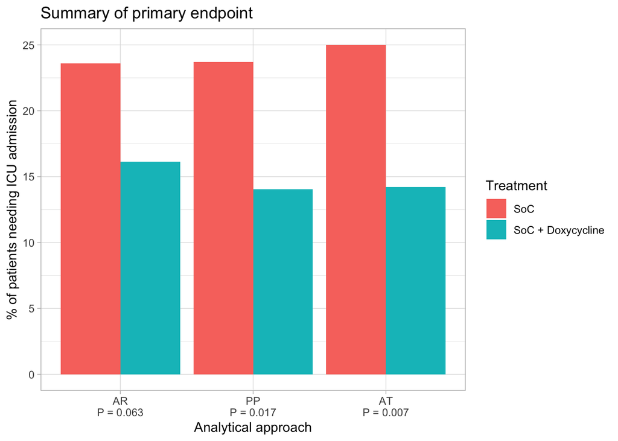

## Raw data

Selected information on patients who died

| Pat ID | Treatment | Consent | ICU? | ICU date | ICU success? | ICU discharge | Hosp discharge | Date of death | Alive? | IorD14? |
| --- | --- | --- | --- | --- | --- | --- | --- | --- | --- | --- |
| 008-0076 | Doxycycline | 2021-04-07 | Yes | 2021-04-13 | 0 | NA | NA | 2021-05-03 | No | Yes |
| 008-0079 | SOC | 2021-04-12 | Yes | 2021-04-15 | 0 | NA | NA | 2021-04-28 | No | Yes |
| 008-0083 | SOC | 2021-04-16 | Yes | 2021-04-19 | 0 | NA | NA | 2021-04-29 | No | Yes |
| 008-0092 | Doxycycline | 2021-04-17 | Yes | 2021-04-21 | 0 | NA | NA | 2021-05-02 | No | Yes |
| 008-0111 | Doxycycline | 2021-04-21 | Yes | 2021-04-28 | NA | NA | NA | 2021-04-30 | No | Yes |
| 008-0119 | Doxycycline | 2021-04-22 | Yes | 2021-04-29 | NA | NA | NA | 2021-04-29 | No | Yes |
| 008-0124 | Doxycycline | 2021-04-23 | Yes | 2021-04-26 | 0 | NA | NA | 2021-05-14 | No | Yes |
| 008-0126 | SOC | 2021-04-23 | Yes | 2021-04-26 | 0 | NA | NA | 2021-05-06 | No | Yes |
| 008-0143 | Doxycycline | 2021-04-23 | Yes | 2021-04-25 | 0 | NA | NA | 2021-05-10 | No | Yes |
| 008-0144 | SOC | 2021-04-23 | Yes | 2021-04-28 | 0 | NA | NA | 2021-04-30 | No | Yes |
| 008-0147 | Doxycycline | 2021-04-25 | Yes | 2021-04-28 | 0 | NA | NA | 2021-05-11 | No | Yes |
| 008-0148 | Doxycycline | 2021-04-25 | Yes | 2021-04-27 | 0 | NA | NA | 2021-05-12 | No | Yes |
| 008-0157 | SOC | 2021-04-26 | Yes | 2021-04-28 | NA | NA | NA | 2021-05-12 | No | Yes |
| 008-0162 | SOC | 2021-04-26 | Yes | 2021-05-02 | 0 | NA | NA | 2021-05-06 | No | Yes |
| 008-0163 | SOC | 2021-04-27 | Yes | 2021-04-29 | 0 | NA | NA | 2021-05-12 | No | Yes |
| 008-0164 | SOC | 2021-04-27 | Yes | 2021-04-30 | 0 | NA | NA | 2021-05-04 | No | Yes |
| 008-0165 | Doxycycline | 2021-04-27 | Yes | 2021-04-29 | 0 | NA | NA | 2021-05-06 | No | Yes |
| 008-0169 | SOC | 2021-04-28 | Yes | 2021-04-29 | 0 | NA | NA | 2021-05-12 | No | Yes |
| 008-0176 | Doxycycline | 2021-04-28 | Yes | 2021-05-03 | 0 | NA | NA | 2021-05-15 | No | Yes |
| 008-0177 | SOC | 2021-04-28 | Yes | 2021-05-03 | 0 | NA | NA | 2021-05-10 | No | Yes |
| 008-0182 | SOC | 2021-04-29 | Yes | 2021-05-01 | 0 | NA | NA | 2021-05-12 | No | Yes |
| 008-0188 | Doxycycline | 2021-04-30 | Yes | 2021-05-05 | 0 | NA | NA | 2021-05-23 | No | Yes |
| 008-0197 | SOC | 2021-05-03 | Yes | 2021-05-05 | 0 | NA | NA | 2021-05-27 | No | Yes |
| 008-0198 | Doxycycline | 2021-05-03 | Yes | 2021-05-04 | NA | NA | NA | 2021-05-04 | No | Yes |
| 008-0199 | Doxycycline | 2021-05-03 | Yes | 2021-05-04 | NA | NA | NA | 2021-05-06 | No | Yes |
| 008-0206 | Doxycycline | 2021-05-03 | Yes | 2021-05-12 | 0 | NA | NA | 2021-05-23 | No | Yes |
| 008-0219 | Doxycycline | 2021-05-04 | Yes | 2021-05-10 | 0 | NA | NA | 2021-05-22 | No | Yes |
| 008-0221 | SOC | 2021-05-04 | Yes | 2021-05-08 | 0 | NA | NA | 2021-05-12 | No | Yes |
| 008-0226 | Doxycycline | 2021-05-04 | Yes | 2021-05-06 | 0 | NA | NA | 2021-05-12 | No | Yes |
| 008-0227 | SOC | 2021-05-05 | Yes | 2021-05-05 | NA | NA | NA | 2021-05-05 | No | Yes |
| 008-0235 | SOC | 2021-05-05 | Yes | 2021-05-06 | NA | NA | NA | 2021-05-10 | No | Yes |
| 008-0236 | SOC | 2021-05-05 | Yes | 2021-05-08 | NA | NA | NA | 2021-06-08 | No | Yes |
| 008-0239 | Doxycycline | 2021-05-06 | Yes | 2021-05-06 | NA | NA | NA | 2021-05-12 | No | Yes |
| 008-0242 | SOC | 2021-05-07 | Yes | 2021-05-12 | 0 | NA | NA | 2021-05-22 | No | Yes |
| 012-0016 | SOC | 2021-01-14 | Yes | 2021-01-21 | NA | NA | NA | 2021-01-21 | No | Yes |
| 012-0028 | Doxycycline | 2021-03-01 | Yes | 2021-03-10 | NA | NA | NA | 2021-03-10 | No | Yes |
| 020-0020 | SOC | 2021-01-08 | Yes | NA | NA | NA | NA | NA | No | Yes |
| 020-0034 | Doxycycline | 2021-03-05 | Yes | NA | 0 | NA | NA | 2021-03-08 | No | Yes |
| 020-0042 | SOC | 2020-12-22 | Yes | 2020-12-22 | 0 | NA | NA | 2020-12-28 | No | Yes |

Summary of reasons for non-admission to ICU

[output not shown]

The listing below demonstrates that there are no patients with missing reasons for non-admission to ICU. The row above with Admission needed? = “Yes” and Reason for admission = NA appears to be incorrect.

```r
data %>%
  filter(ICUAdmissionNeeded == 1, ICUAdmissionSuccess == 0) %>%
  dplyr::select(SiteID, PatNo, Stratum, ICDate, Treatment, ICUAdmissionNeeded, ICUAdmissionSuccess, ICUNonAdmissionReason) %>%
  kable(caption="Patients with missing reasons for non-admission to ICU") %>%
  kable_styling(bootstrap_options = c("striped", "hover", "condensed"))
```

Patients with missing reasons for non-admission to ICU

| SiteID | PatNo | Stratum | ICDate | Treatment | ICUAdmissionNeeded | ICUAdmissionSuccess | ICUNonAdmissionReason |
| --- | --- | --- | --- | --- | --- | --- | --- |
| 020 | 0034 | NONE | 2021-03-05 | Doxycycline | 1 | 0 | 1 |
| 020 | 0042 | OTHER | 2020-12-22 | Standard of Care | 1 | 0 | 1 |
| 008 | 0076 | OTHER | 2021-04-07 | Doxycycline | 1 | 0 | 3 |
| 008 | 0079 | LUNG | 2021-04-12 | Standard of Care | 1 | 0 | 3 |
| 008 | 0083 | OTHER | 2021-04-16 | Standard of Care | 1 | 0 | 1 |
| 008 | 0092 | OTHER | 2021-04-17 | Doxycycline | 1 | 0 | 3 |
| 008 | 0124 | OTHER | 2021-04-23 | Doxycycline | 1 | 0 | 1 |
| 008 | 0126 | LUNG | 2021-04-23 | Standard of Care | 1 | 0 | 1 |
| 008 | 0143 | OTHER | 2021-04-23 | Doxycycline | 1 | 0 | 1 |
| 008 | 0144 | OTHER | 2021-04-23 | Standard of Care | 1 | 0 | 3 |
| 008 | 0147 | LUNG | 2021-04-25 | Doxycycline | 1 | 0 | 1 |
| 008 | 0148 | OTHER | 2021-04-25 | Doxycycline | 1 | 0 | 1 |
| 008 | 0162 | LUNG | 2021-04-26 | Standard of Care | 1 | 0 | 3 |
| 008 | 0163 | LUNG | 2021-04-27 | Standard of Care | 1 | 0 | 3 |
| 008 | 0164 | OTHER | 2021-04-27 | Standard of Care | 1 | 0 | 3 |
| 008 | 0165 | OTHER | 2021-04-27 | Doxycycline | 1 | 0 | 1 |
| 008 | 0169 | OTHER | 2021-04-28 | Standard of Care | 1 | 0 | 1 |
| 008 | 0176 | OTHER | 2021-04-28 | Doxycycline | 1 | 0 | 3 |
| 008 | 0177 | OTHER | 2021-04-28 | Standard of Care | 1 | 0 | 3 |
| 008 | 0182 | OTHER | 2021-04-29 | Standard of Care | 1 | 0 | 1 |
| 008 | 0188 | NONE | 2021-04-30 | Doxycycline | 1 | 0 | 1 |
| 008 | 0197 | LUNG | 2021-05-03 | Standard of Care | 1 | 0 | 1 |
| 008 | 0206 | LUNG | 2021-05-03 | Doxycycline | 1 | 0 | 3 |
| 008 | 0219 | OTHER | 2021-05-04 | Doxycycline | 1 | 0 | 3 |
| 008 | 0221 | OTHER | 2021-05-04 | Standard of Care | 1 | 0 | 3 |
| 008 | 0226 | OTHER | 2021-05-04 | Doxycycline | 1 | 0 | 1 |
| 008 | 0242 | OTHER | 2021-05-07 | Standard of Care | 1 | 0 | 3 |

```r
data %>%
  mutate(
    FinalStatusText=case_when(
                      FinalStatus == 1 ~ "Completed",
                      FinalStatus == 2 ~ "Discharged",
                      FinalStatus == 3 ~ "DC (AE)",
                      FinalStatus == 4 ~ "DC (Other)",
                      FinalStatus == 5 ~ "Lost",
                      FinalStatus == 6 ~ "Consent",
                      FinalStatus == 7 ~ "Other",
                      FinalStatus == 8 ~ "Died",
                      TRUE ~ "Missing"
                    )
  ) %>%
  dplyr::select(SiteID, PatNo, Stratum, ICDate, Treatment, ICUAdmissionNeeded, ICUAdmissionNeededDate, DateOfDeath, FinalStatusText) %>%
  kable() %>%
  kable_styling(bootstrap_options = c("striped", "hover", "condensed"))
```

| SiteID | PatNo | Stratum | ICDate | Treatment | ICUAdmissionNeeded | ICUAdmissionNeededDate | DateOfDeath | FinalStatusText |
| --- | --- | --- | --- | --- | --- | --- | --- | --- |
| 011 | 0001 | LUNG | 2021-02-04 | Standard of Care | 0 | NA | NA | Completed |
| 015 | 0001 | NA | NA | NA | NA | NA | NA | Missing |
| 013 | 0001 | OTHER | 2020-12-09 | Doxycycline | 0 | NA | NA | Missing |
| 013 | 0002 | OTHER | 2021-01-03 | Standard of Care | 0 | NA | NA | Missing |
| 013 | 0003 | OTHER | 2021-01-01 | Standard of Care | 0 | NA | NA | Missing |
| 013 | 0004 | OTHER | 2021-01-03 | Standard of Care | 0 | NA | NA | Missing |
| 013 | 0005 | OTHER | 2020-12-30 | Standard of Care | 0 | NA | NA | Missing |
| 020 | 0001 | NONE | 2020-12-21 | Standard of Care | 0 | NA | NA | Discharged |
| 020 | 0002 | NONE | 2020-12-16 | Standard of Care | 0 | NA | NA | Discharged |
| 020 | 0003 | NONE | 2020-12-20 | Standard of Care | 0 | NA | NA | Discharged |
| 020 | 0004 | NONE | 2020-12-20 | Doxycycline | 0 | NA | NA | Completed |
| 020 | 0005 | OTHER | 2020-12-21 | Doxycycline | 0 | NA | NA | Completed |
| 020 | 0006 | LUNG | 2020-12-21 | Doxycycline | 0 | NA | NA | Discharged |
| 020 | 0007 | OTHER | 2020-12-15 | Standard of Care | 1 | 2020-12-15 | NA | Discharged |
| 020 | 0008 | LUNG | 2020-12-11 | Doxycycline | 1 | 2020-12-11 | NA | Completed |
| 020 | 0009 | LUNG | 2020-12-11 | Standard of Care | 0 | NA | NA | Completed |
| 020 | 0010 | LUNG | 2020-12-21 | Standard of Care | 1 | 2020-12-21 | NA | DC (Other) |
| 020 | 0011 | OTHER | 2020-12-25 | Doxycycline | 0 | NA | NA | Completed |
| 020 | 0012 | NONE | 2020-12-24 | Doxycycline | 0 | NA | NA | Discharged |
| 012 | 0001 | OTHER | 2020-11-01 | Standard of Care | 0 | NA | NA | Discharged |
| 012 | 0002 | LUNG | 2020-11-02 | Standard of Care | 1 | 2020-11-01 | NA | Completed |
| 012 | 0003 | NONE | 2020-11-15 | Doxycycline | 0 | NA | NA | Completed |
| 013 | 0006 | NA | NA | NA | NA | NA | NA | Missing |
| 013 | 0007 | NA | NA | NA | NA | NA | NA | Missing |
| 013 | 0008 | NA | NA | NA | NA | NA | NA | Missing |
| 013 | 0009 | NA | NA | NA | NA | NA | NA | Missing |
| 013 | 0010 | NA | NA | NA | NA | NA | NA | Missing |
| 013 | 0011 | NA | NA | NA | NA | NA | NA | Missing |
| 020 | 0013 | OTHER | 2020-12-30 | Standard of Care | 0 | NA | NA | Discharged |
| 020 | 0014 | LUNG | 2020-12-30 | Standard of Care | 0 | NA | NA | Discharged |

[output cut: 371 more lines]